# Statistical Learning Experiment

# Summary of datasets

# Statistical Learning Tests

Our first step is just to make sure people are behaving sensibly on the SL tasks, and to check if there are differences in overall performance by condition.

## Part 1

First let’s look at the histograms of all responses to determine whether they look like those reported in Seigelman et al., 2017, and to see whether the data look normal. This includes the Lᴇᴛᴛᴇʀ and Cᴏᴍᴘʟᴇx conditions, as well as Sɪᴍᴘʟᴇ (explained below).

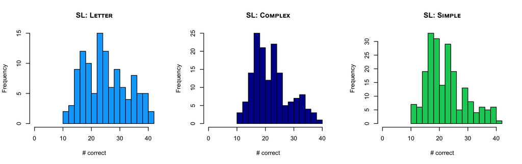

These look pretty reasonable as well. Is the accuracy different between conditions?

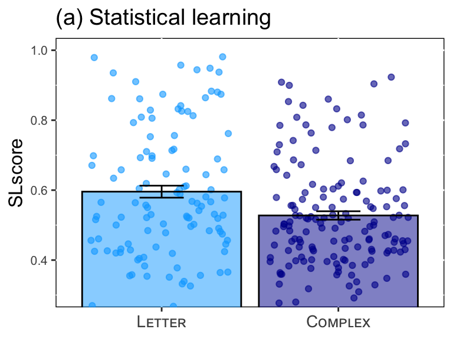

It looks like indeed there is a difference in performance. To evaluate this statistically we ran a t-test with accuracy as our outcome variable and condition as predictor.

Performance in both conditions is different from chance when chance is calculated as 16.75/42 (Lᴇᴛᴛᴇʀ: t(112)= 11.45, p=0, d=1.077; Cᴏᴍᴘʟᴇx: t(150)= 10.69, p=0, d=0.87). We find the same thing if we use a non-parametric alternative to the t-test, the Wilcoxon: Lᴇᴛᴛᴇʀ: V=6119, p=0; Cᴏᴍᴘʟᴇx: V=1.050810^{4}, p=0.

The results of the t-test are also significant (t(211)=3.24, p=0.0014, d=0.415), and this doesn’t change if we use a Wilcoxon instead: W=1.040510^{4}, p=0.0022. A Bayesian t-test with default priors for effect size finds that the data were 25.0846356 in favour of the alternative hypothesis (i.e., were 25.0846356 times more likely to occur under the model that performance is different by condition).

We might also care about whether people’s behaviour showed the same *pattern* as Siegelman et al., 2017: that is, were the test items that their participants found hard the same test items that our participants found hard? We can evaluate this by calculating the correlation between performance on each item between them (which they reported) and our data. It is evident that all correlations are highly significant.

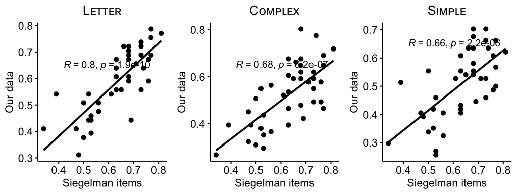

# Perceptual Fluency Tasks

So far it seems that the statistical learning tasks are behaving as expected, and we’re getting significant differences in performances based on the visual complexity / familiarity of the stimuli involved. Let’s also check that the perceptual fluency tasks are behaving in a sensible fashion. This is a bit harder because they are new tasks so there’s no published literature to compare to, but as a first stab we can look at what happens to the duration that the target item flashes over the course of the task (which I’ll refer to as the *lag time*). Remember that it gets faster when people are more accurate, so we should expect that in easier tasks it should end up being on average faster. We should also expect it to stabilise somewhere.

We can make two comparisons. First, remember that each person saw two perceptual fluency tasks in a row. We might be curious about whether performance changes between the tasks, either due to fatigue or practice effects. Thus, the figure on the left below shows overall performance on the First and Second task. Second, some people saw perceptual fluency tasks with Lᴇᴛᴛᴇʀ items, and some with Cᴏᴍᴘʟᴇx items. If the length that the item flashes is really related to their complexity, we would expect that in the Lᴇᴛᴛᴇʀ condition it doesn’t need to flash as long. This is shown in the figure on the right.

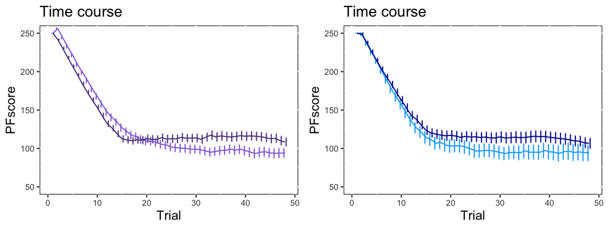

Some things are immediately obvious. First, reassuringly, the time each stimulus flashed does go down, and doesn’t bobble around. Second, it appears as though there are differences in both order (people are faster for the first task, so fatigue may be a factor) and condition (people are faster for the Lᴇᴛᴛᴇʀ items, which is nice). However, we don’t know if these effects are significant.

Unfortunately, we can’t run statistical tests on multiple different trials, because the trials are all very non-trivially dependent on each other. We therefore feed each person’s average lag time in and test whether these differ by order or condition.

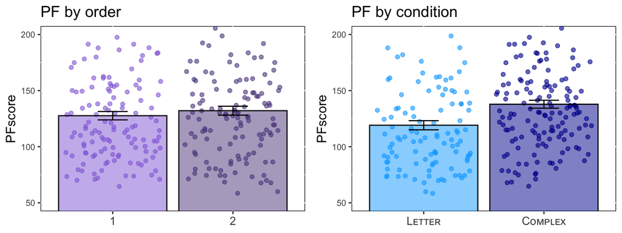

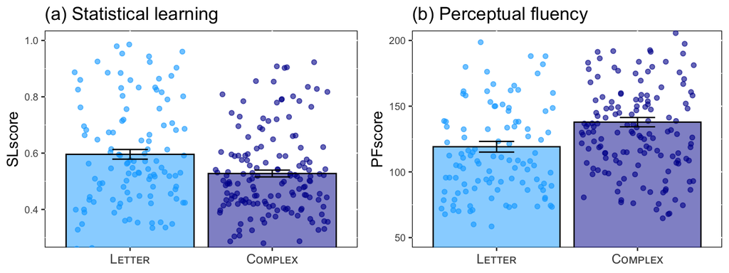

Is this significant? In order to evaluate this, I ran two separate t-tests, one looking at lagtime by test order (i.e., corresponding to the figure on the left) and one at lagtime by condition (i.e., corresponding to the figure on the right). Order was not significant (t(260.1)=-0.81, p=0.4172, d=0.1) but condition was (t(240.1)=-3.46, p=0.0006, d=0.431). We get the same results if we run a Wilcoxon: order W=8059.5, p=0.3421, condition W=6016, p=10^{-4}. This is pretty cool: it means that, as predicted, people did better on the perceptual fluency task when the stimulus items involved were Lᴇᴛᴛᴇʀ ones. That said, performance on the two back-to-back perceptual fluency tasks was of course also highly correlated with one another (r = 0.5424, p<0.0001, pearson; rho = 0.4363, p<0.0001, spearman).

Of course, these overall correlations with each other could just be because they were back-to-back. One wonders to what extent the PF task is reflecting stimulus-dependent learning vs general efficient processing speed. To kind of get a sense of this, we can compare correlations in the PF task for the people who saw the same stimulus type both times vs a different stimulus type both times, as below:

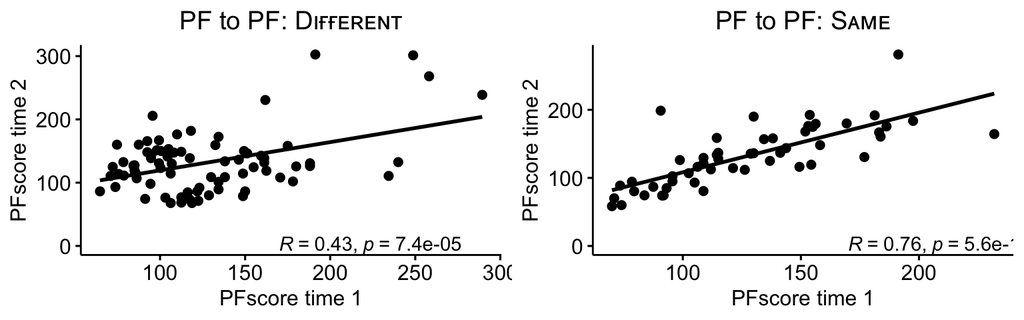

We can statistically test this with the Fisher r-to-z transformation: z=2.8720315, p=0.0040784.

Let’s also break the same one down to whether the stimuli were Lᴇᴛᴛᴇʀ or Cᴏᴍᴘʟᴇx

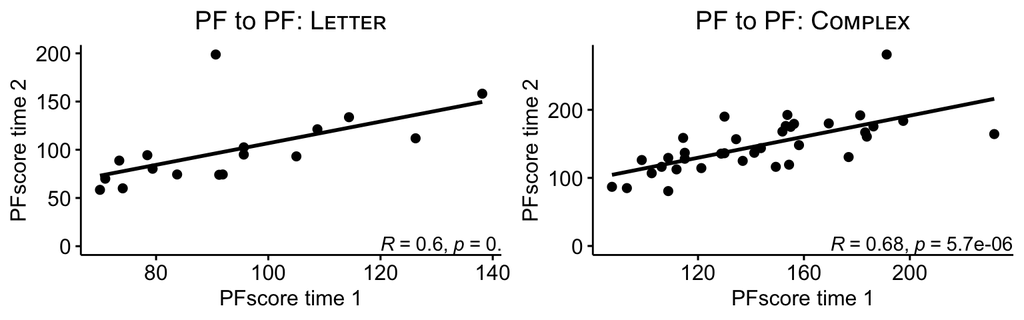

We can statistically test this with the Fisher r-to-z transformation: z=-0.3996869, p=0.6893872.

Finally, next, we really get to look at the meat of our experiment: how these measures relate to each other.

# Relation of statistical learning to statistical learning

Our first question is how people’s statistical learning performance on the two separate days compares to each other. As you’ll recall, some people saw the Sᴀᴍᴇ kinds of stimulus sets on both days (either both Lᴇᴛᴛᴇʀ or both Cᴏᴍᴘʟᴇx) and some people saw Dɪғғᴇʀᴇɴᴛ types of stimulus sets (some saw Lᴇᴛᴛᴇʀ on Session 1 and Cᴏᴍᴘʟᴇx on Session 2, and some vice-versa). In no case did anybody see the same *items* on both days – even if it was the same kind of stimulus, the items were different. Thus, for instance, if your stimulus contained a star on Session 1 then it did not contain a star on Session 2. This means that any correlation in performance cannot be explained by trivial familiarity with the specific stimulus items.

Our key question is whether people who saw the Sᴀᴍᴇ kind of stimulus set on both days had a higher correlation in their statistical learning accuracy between tasks than people who saw Dɪғғᴇʀᴇɴᴛ stimulus sets. If individual differences in performance on this task are *just* about statistical learning, these correlations should be the same, since the underlying statistical learning is exactly the same – all that differs is the stimulus type. If, on the other hand, perceptual fluency plays an important role, then one would expect a larger correlation for people who saw the Sᴀᴍᴇ stimulus sets and a smaller (or nonexistent) one for people who saw Dɪғғᴇʀᴇɴᴛ ones. These correlations are shown below.

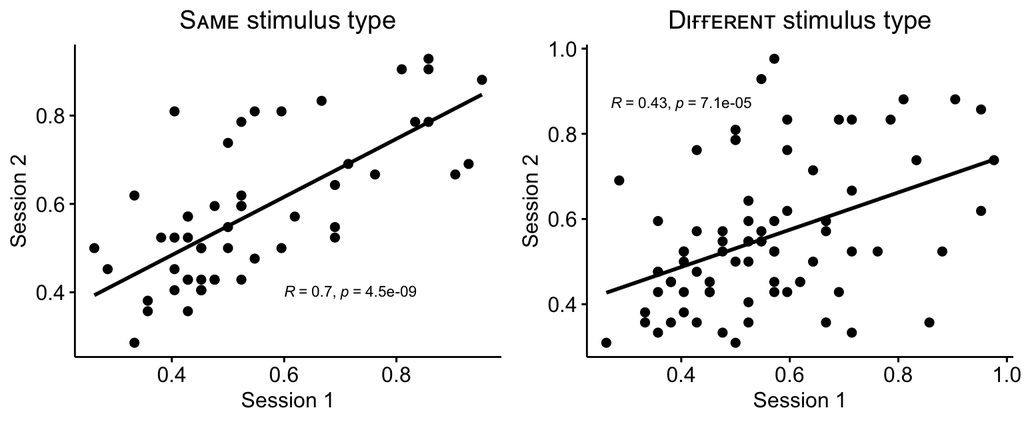

It is indeed apparent that Sᴀᴍᴇ appears to correlate with each other much better than Dɪғғᴇʀᴇɴᴛ. The correlation among the Sᴀᴍᴇ stimuli is 0.703, p=0 and among Dɪғғᴇʀᴇɴᴛ stimuli is 0.432, p=10^{-4} We can statistically test whether these are different from each other with the Fisher r-to-z transformation: z=2.2554213, p=0.0241069. So these are indeed significantly different.

Within the Sᴀᴍᴇ stimuli, we can also look at whether there is a difference when both are Lᴇᴛᴛᴇʀ or both are Cᴏᴍᴘʟᴇx That is shown below.

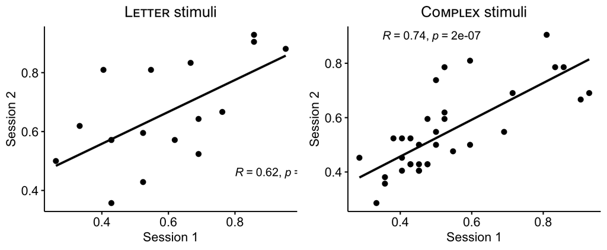

It looks like the correlation is slightly larger with Cᴏᴍᴘʟᴇx stimuli. The Fisher r-to-z transformation shows: z=-0.7218004, p=0.4704172 which means that this difference is not itself significant.

# Relation of statistical learning to perceptual fluency

Given the hypotheses of our study, we’re also interested in determining whether performance on the perceptual fluency task predicts performance on the statistical learning task. If familiarity/complexity mediates this, we would expect that PFscore and SL score would be more highly correlated when the stimuli were the same and when they were different.

The stimuli were only different for people in the Dɪғғᴇʀᴇɴᴛ condition. Since I made it so the first PF task always used the stimuli from the first SL task, that means that comparing different stimuli involved comparing the first PF task to the second SL task and the second PF task to the first SL task.

To make the correlation calculation for the same-stimuli equivalent, then, I focused on people in the Sᴀᴍᴇ condition and the same trials (the first PF task to the second SL task and the second PF task to the first SL task). These results are shown below.

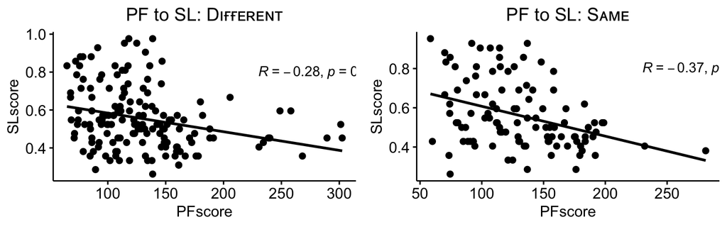

So having a shorter lag time on the perceptual fluency task is correlated with being more accurate on the statistical learning task. In addition, this relationship is stronger when the stimuli are the same than when they were different. This difference is itself non-signficant: Fisher r-to-z transformation: z=-0.7590302, p=0.4478345.

For the same stimuli, we can break it down by whether they were Lᴇᴛᴛᴇʀ or Cᴏᴍᴘʟᴇx.

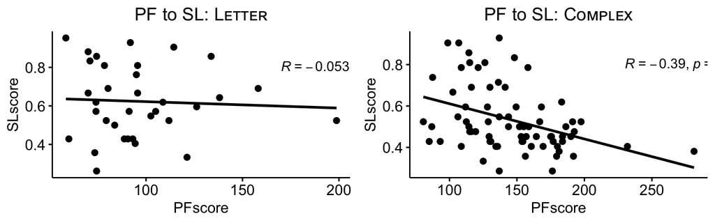

This is kind of interesting. It’s cool that the PF test does a reasonable job predicting statistical learning performance. It’s also interesting that the relationship exists mainly for the Cᴏᴍᴘʟᴇx stimuli (possibly because the Lᴇᴛᴛᴇʀ ones are so overlearned there’s less room for individual differences?). This difference is itself non-significant however: Fisher r-to-z transformation: z=1.6754999, p=0.0938362.

It should be noted that the strength of the relationship between perceptual fluency and statistical learning is less strong than between statistical learning on two consecutive days, even when the stimuli are different. So that’s an indication that there is some important component of statistical learning the perceptual fluency doesn’t touch. Still, it’s kind of impressive how much does just come down to perceptual fluency.

## Overall

1. People don’t do as well on statistical learning tasks that are identical in terms of statistical complexity but that have more complex stimuli. (2) Statistical learning performance from one day to another is more highly correlated when the items involved are similar, even though in both cases the statistical complexity is the same. (3) Performance on an independent task of perceptual fluency predicts accuracy on the statistical learning task from a previous day.

## Compare to simpler unknown stimuli

Is this familiarity or complexity? Let’s compare SL performance in the Lᴇᴛᴛᴇʀ and Cᴏᴍᴘʟᴇx conditions to a condition that uses unfamiliar stimuli that are also substantially simpler visually. For this we ran 80 people on AMT in exactly the same experiment but with different stimuli, which again took 15-20 minutes and paid $3.40USD. Before analysing the data 6 were excluded for getting less than three of the four words in the sequence right. This left 74 people in the dataset, in what well call the Sɪᴍᴘʟᴇ condition. In this condition, 46 (i.e., 62.2%) were male and 70 (i.e., 94.6%) were from the US. Ages ranged from 21 to 62 with a mean of 36.4.

Is the accuracy different between conditions? To look at this we compare SL performance on all of the *first session* datasets (not like the one before for Lᴇᴛᴛᴇʀ and Cᴏᴍᴘʟᴇx, which included both days). The reason we just look at first session is to make Sɪᴍᴘʟᴇ comparable to the others, since it had only one session – it doesn’t matter much but seems more principled. Anyway, the result is shown below.

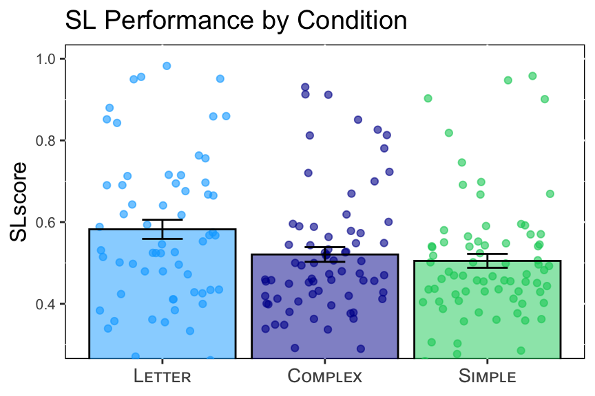

It looks like indeed there is a difference in performance. To evaluate this statistically we ran a one-way ANOVA with accuracy as our outcome variable and condition as predictor.

We find the same result when we do the equivalent non-parametric tests. A Kruskal-Wallis found a significant effect of condition, X<sup>2</sup>=7.34, p=0.0255. Post-hoc pairwise tests with the Wilcoxon found a significant difference between Lᴇᴛᴛᴇʀ and Sɪᴍᴘʟᴇ (W=2841, p=0.0098) and Lᴇᴛᴛᴇʀ and Cᴏᴍᴘʟᴇx (W=2620, p=0.038) but not Cᴏᴍᴘʟᴇx and Sɪᴍᴘʟᴇ (W=2504.5, p=0.6285).

# Double-checking analyses using only first session

Unless explicitly noted otherwise, all of the previous analyses pooled together the scores from the first and second session. In order to be sure, here we redo everything using just the scores from the first person (on the reasoning that it is most like other studies).

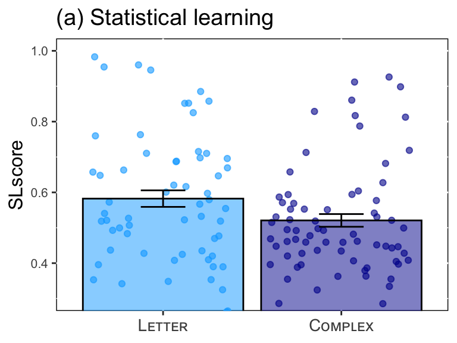

It looks like indeed there is a difference in performance. To evaluate this statistically we ran a t-test with accuracy as our outcome variable and condition as predictor.

Performance in both conditions is different from chance when chance is calculated as 16.75/42 (Lᴇᴛᴛᴇʀ: t(60)= 7.87, p=0, d=1.007; Cᴏᴍᴘʟᴇx: t(70)= 6.79, p=0, d=0.806). We find the same thing if we use a non-parametric alternative to the t-test, the Wilcoxon: Lᴇᴛᴛᴇʀ: V=1760, p=0; Cᴏᴍᴘʟᴇx: V=2326, p=0.

The results of the t-test are also significant (t(117)=2.09, p=0.0387, d=0.37), and this doesn’t change if we use a Wilcoxon instead: W=2620, p=0.038. A Bayesian t-test with default priors for effect size finds that the data were 1.4167412 in favour of the alternative hypothesis (i.e., were 1.4167412 times more likely to occur under the model that performance is different by condition).

Let’s also look at perceptual fluency in just the first session.

```
## # A tibble: 2 x 5
##   PFtype   mean    sd     n    se
## * <fct>   <dbl> <dbl> <int> <dbl>
## 1 Lᴇᴛᴛᴇʀ   118.  40.8    61  5.22
## 2 Cᴏᴍᴘʟᴇx  135.  43.3    71  5.14
```

[figure not shown]